# Breakpoint

2021-09-27

> If you want the ultimate, you’ve got to be willing to pay the ultimate price. It’s not tragic to die doing what you love. — Bodhi, Break Point

En la clase se van a ver temas más avanzados, los alumnos deberán evaluar si deciden aplicar estás técnicas en esta primera competencia, pero sin lugar a dudas deberán aplicarlas en la segunda.

Empecemos con algo que quedo en el tintero de la clase anterior, y que está conectado con la última parte de la clase.

En el enorme espacio de la creación de **feature engineering**, hay algoritmos para la creación de nuevos **features automáticos**.

Una *empresita* llamada *Facebook* publicó hace unos años el paper:

[Practical Lessons from Predicting Clicks on Ads at Facebook](https://research.fb.com/publications/practical-lessons-from-predicting-clicks-on-ads-at-facebook/)

Donde plantea que utilizar los *leaves* de los árboles como nuevas variables. Los gigantes de `xgboost` lo implementaron en su librería.

Veamos como funciona, incluso usando `lightgbm` como algoritmo.

```r
rm( list=ls() )
gc()
```

```
##          used (Mb) gc trigger (Mb) max used (Mb)
## Ncells 456371 24.4     971142 51.9   665548 35.6
## Vcells 848959  6.5    8388608 64.0  1813014 13.9
```

```r
library("data.table")
library("lightgbm")
carpeta_datasetsOri <-  "../../../datasetsOri/"
septiembre <- "paquete_premium_202009.csv"


ds <- fread(paste0(carpeta_datasetsOri, septiembre,collapse = ""), showProgress = FALSE)
clase_binaria <- ifelse(ds$clase_ternaria == "BAJA+2", 1, 0)
ds$clase_ternaria <- NULL
```

Lo primero que tenemos que hacer es armar un modelo.

```r
library(xgboost)
dtrain <- xgb.DMatrix(data=data.matrix(ds), label=  clase_binaria, missing=NA)
param_fe <- list(max_depth=2, eta=1, silent=1, objective='binary:logistic')
nrounds = 5

bst = xgb.train(params = param_fe, data = dtrain, nrounds = nrounds)
```

[output not shown]

Luego se generan las *features* extras

```r
new.features.train <- xgb.create.features(model = bst, data.matrix(ds))
colnames(new.features.train)[150:173]
```

```
##  [1] "Visa_mpagado"            "Visa_mpagospesos"
##  [3] "Visa_mpagosdolares"      "Visa_fechaalta"
##  [5] "Visa_mconsumototal"      "Visa_cconsumos"
##  [7] "Visa_cadelantosefectivo" "Visa_mpagominimo"
##  [9] "V13"                     "V14"
## [11] "V15"                     "V16"
## [13] "V24"                     "V25"
## [15] "V26"                     "V34"
## [17] "V35"                     "V36"
## [19] "V44"                     "V45"
## [21] "V46"                     "V54"
## [23] "V55"                     "V56"
```

Y podemos visualizar los árboles de nuestro ensamble generador de *features* para entender la composición de las nuevas variables

```r
xgb.plot.tree(colnames(new.features.train), bst,trees = 0)
```

[interactive chart not shown]

Podemos entrenar usando en un **lightgbm** sin muchos problemas

```r
dtrain_lgb  <- lgb.Dataset( data= data.matrix(new.features.train), label= clase_binaria )

params_gbdt <- list( objective= "binary", max_bin= 15, min_data_in_leaf= 4000, learning_rate= 0.05 )

mlgb <- lgb.train(dtrain_lgb, params = params_gbdt, verbose = -1)
```

Y podemos ver cuál es la importancia de variables

```r
lgb.importance(mlgb)
```

| Feature | Gain | Cover | Frequency |
| --- | --- | --- | --- |
| V36 | 9.992391e-02 | 2.104179e-02 | 0.0050000000 |
| ctrx_quarter | 9.815932e-02 | 1.143777e-02 | 0.0120000000 |
| cpayroll_trx | 9.395745e-02 | 6.585954e-02 | 0.0196666667 |
| V26 | 7.851067e-02 | 8.163251e-03 | 0.0030000000 |
| V15 | 5.664722e-02 | 2.753176e-03 | 0.0023333333 |
| mcuentas_saldo | 2.961498e-02 | 2.687582e-02 | 0.0363333333 |
| ctarjeta_visa_transacciones | 2.862187e-02 | 1.912062e-02 | 0.0200000000 |
| mprestamos_personales | 2.577097e-02 | 3.880815e-02 | 0.0213333333 |
| Visa_mpagominimo | 2.422421e-02 | 2.633057e-02 | 0.0306666667 |
| mactivos_margen | 2.173005e-02 | 1.876844e-02 | 0.0206666667 |

[output cut: 98 more lines]

O sea, para esta parametrización, suma variables de importantes.

**Pregunta**

- ¿Significa esto que va a dar mejor este conjunto de datos?
- ¿Sería necesario buscar nuevos hiperparámetros para nuestro **lgbm**? ¿ y para nuestro **xgb** que genera los *features*?
- ¿Cómo podría implementar un **pipeline** para incorporar este tipo de variables o variables similares?

Dejemos en suspenso este punto. Volveremos en un rato con una visión más general.

Validemos si ocurre lo mismo en un nuestros algoritmos.

Vamos a apoyarnos en una función que busque para todos los puntos de corte, el que más ganancia genera.

```r
ganancia  <- function(score, clases, cp= 0.025, prop=1){
  return( sum( (score > cp  )*ifelse( clases== 1, 48750, -1250 ) ) / prop )
}

mejorpuntocorte <- function(score, clases, prop=1) {

  tmp <- data.table(score, clases)

  tmp[, v := ifelse(clases == 1, 48750,-1250)]
  tmp2 <- tmp[, .(gan = sum(v)), by = score]
  tmp2 <- tmp2[order(-score)]
  tmp2[, ganancia := cumsum(gan)]
  tmp2[, ganancia := ganancia / prop]
  maxganancia <- tmp2[max(ganancia) == ganancia, ganancia]
  puntocorte <- tmp2[max(ganancia) == ganancia, score]
  list(gan=maxganancia, cp=puntocorte)
}
```

Y buscamos en **train** cuál es el mejor punto de corte

```r
dtrain_lgb  <- lgb.Dataset( data= data.matrix(ds), label= clase_binaria )
mlgb <- lgb.train(dtrain_lgb, params = params_gbdt, verbose = -1)
probs <- predict(mlgb, data.matrix(ds))
mejorpuntocorte(probs, clase_binaria)$cp
```

```
## [1] 0.02248277
```

Podemos pensar que entre el punto el mejor punto de corte y nuestro punto de corte teórico no hay valores existentes, como sucedía con los árboles.

```r
head(probs[probs > 0.021 & probs < 0.025])
```

```
## [1] 0.02430849 0.02476261 0.02292336 0.02294598 0.02472430 0.02110568
```

```r
tail(probs[probs > 0.021 & probs < 0.025])
```

```
## [1] 0.02151278 0.02122358 0.02188389 0.02253811 0.02155209 0.02410442
```

Vemos que el mejor punto de corte no es necesariamente el teórico.

**Pregunta**

- ¿Por qué sucede esto?

Luego tendríamos que ver como podemos buscar el punto de corte. Una opción es con **CV**

```r
folds <- splitTools::create_folds(clase_binaria, k = 5, seed = 17)
res <- data.table()

# Vamos a almacenar todos los scores de validación
validation <- numeric(length(clase_binaria))

for (f in folds) {
  ds_train  <- lgb.Dataset( data=  data.matrix(ds[f]), label= clase_binaria[f] )
  m <- lgb.train(ds_train, params = params_gbdt, verbose = -1)
  validation[-f] <- predict(m,data.matrix(ds[-f]))
  res <- rbindlist(list(res, mejorpuntocorte(validation[-f], clase_binaria[-f], 0.2)))
}
```

```r
res
```

| gan | cp |
| --- | --- |
| 6325000 | 0.03378654 |
| 6425000 | 0.02986165 |
| 7725000 | 0.02272103 |
| 6756250 | 0.02424354 |
| 9031250 | 0.02641460 |

**Pregunta**

- ¿Cómo podríamos determinar un mejor punto de corte con este resultado?

Veamos una forma, promediando los mejores puntos

```r
mean(res$cp)
```

```
## [1] 0.02740548
```

Veamos con los datos de validation cuál es el mejor punto de corte

```r
ganancia(validation, clase_binaria)
```

```
## [1] 6400000
```

```r
ganancia(validation, clase_binaria, mean(res$cp))
```

```
## [1] 6547500
```

Otra recomendación, es incluir el punto de corte como un parámetro más dentro de una optimización bayesiana.

También podemos buscar el mejor corte posible sobre el conjunto compuesto por todos los scores obtenidos en los *folds* de validación

```r
mejorpuntocorte(validation, clase_binaria)
```

```
## $gan
## [1] 6852500
##
## $cp
## [1] 0.02946356
```

Sigamos este análisis sobre otros tipos de modelos que pueden ser creados usando el **mágico lightgbm.**

Se puede implementar un "**random forest"**

```r
params_rf <- list(objective = "binary",  boosting_type = "rf", bagging_freq = 1, bagging_fraction = 0.66, feature_fraction = 0.4)
```

Y también los creadores de **lightgbm** crearon una forma distinta de construir los **GBDT**

[LightGBM: A Highly Efficient Gradient Boosting Decision Tree](https://proceedings.neurips.cc/paper/2017/file/6449f44a102fde848669bdd9eb6b76fa-Paper.pdf)

Que promete ser veloz en el ajuste, a cambio de una baja en la performance

```r
params_goss <- list(objective = "binary", learning_rate = 0.05, top_rate = 0.5, other_rate = 0.1, feature_fraction_bynode = 0.2, boosting_type = "goss")
```

Hay un tipo más, los **dart**, que prometen más precisión a un mayor tiempo de entrenamiento, pero los vamos a dejar de lado.

**IMPORTANTE**: No hice búsqueda bayesiana en **goss**, ni en **rf**.

Armamos nuestro propio GBDT CV, para poder personalizar su funcionamiento.

```r
# OJO! Con esta función perdemos cuál es la mejor iteración.

mylgbcv <- function(data, target, params, nfold, seed) {

  folds <- splitTools::create_folds(target, k = nfold, seed = seed)
  res <- data.table()
  validation <- numeric(length(target))
  for (f in folds) {
    ds_train  <- lgb.Dataset( data=  data.matrix(data[f]), label= target[f] )
    m <- lgb.train(ds_train, params = params, verbose = -1)
    validation[-f] <- predict(m,data.matrix(data[-f]))
    res <- rbindlist(list(res, mejorpuntocorte(validation[-f], target[-f], 0.2)))
  }
  list(probs= validation, gan= ganancia(validation, target), bcp = mejorpuntocorte(validation, target), res=res)
}
```

Y ejecutamos las diferentes opciones para compararlas

```r
gbdt <- mylgbcv(ds, clase_binaria, param= params_gbdt, 5, 17)
rf <- mylgbcv(ds, clase_binaria, param= params_rf, 5, 17)
goss <- mylgbcv(ds, clase_binaria, param= params_goss, 5, 17)
```

Revisemos los resultados

```r
gbdt$gan
```

```
## [1] 6400000
```

```r
print("mejor punto de corte según cv")
```

```
## [1] "mejor punto de corte según cv"
```

```r
ganancia(gbdt$probs, clase_binaria, mean(gbdt$res$cp))
```

```
## [1] 6547500
```

```r
print("mejor punto de corte")
```

```
## [1] "mejor punto de corte"
```

```r
gbdt$bcp
```

```
## $gan
## [1] 6852500
##
## $cp
## [1] 0.02946356
```

```r
rf$gan
```

```
## [1] 1617500
```

```r
print("mejor punto de corte según cv")
```

```
## [1] "mejor punto de corte según cv"
```

```r
ganancia(rf$probs, clase_binaria, mean(rf$res$cp))
```

```
## [1] 7028750
```

```r
print("mejor punto de corte")
```

```
## [1] "mejor punto de corte"
```

```r
rf$bcp
```

```
## $gan
## [1] 7137500
##
## $cp
## [1] 0.3356952
```

```r
goss$gan
```

```
## [1] 4443750
```

```r
print("mejor punto de corte según cv")
```

```
## [1] "mejor punto de corte según cv"
```

```r
ganancia(goss$probs, clase_binaria, mean(goss$res$cp))
```

```
## [1] 5301250
```

```r
print("mejor punto de corte")
```

```
## [1] "mejor punto de corte"
```

```r
goss$bcp
```

```
## $gan
## [1] 5520000
##
## $cp
## [1] 0.01858729
```

Vemos que tienen puntos de cortes distintos.

Veamos que tan distintas son las distribuciones para ver si lo único que cambian es el punto de corte.

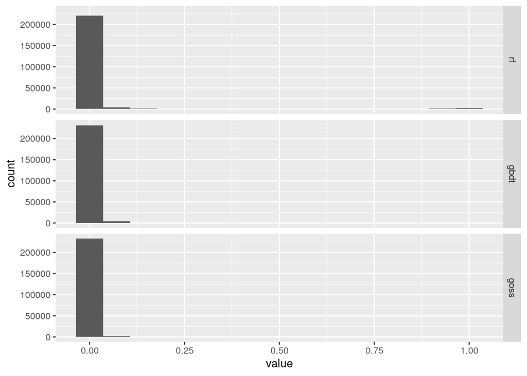

```r
library(ggplot2)
d = data.table(rf=rf$probs,gbdt=gbdt$probs,goss=goss$probs)
ggplot(melt(d), aes(x=value )) +
  facet_grid(variable ~ .) +
  geom_histogram(bins = 15)
```

No pareciera que vaya grandes diferencias en las distribuciones. Comparemos una a una

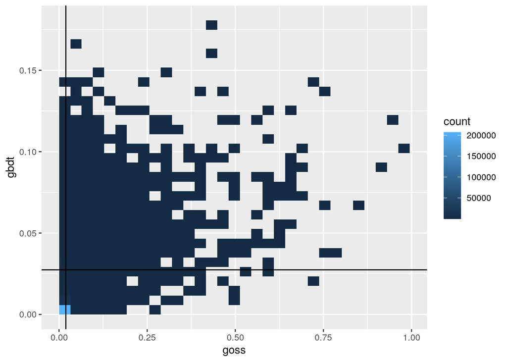

```r
ggplot(d, aes(goss,gbdt)) +
  geom_bin2d() +
  geom_hline(yintercept = mean(gbdt$res$cp)) +
  geom_vline(xintercept = mean(goss$res$cp))
```

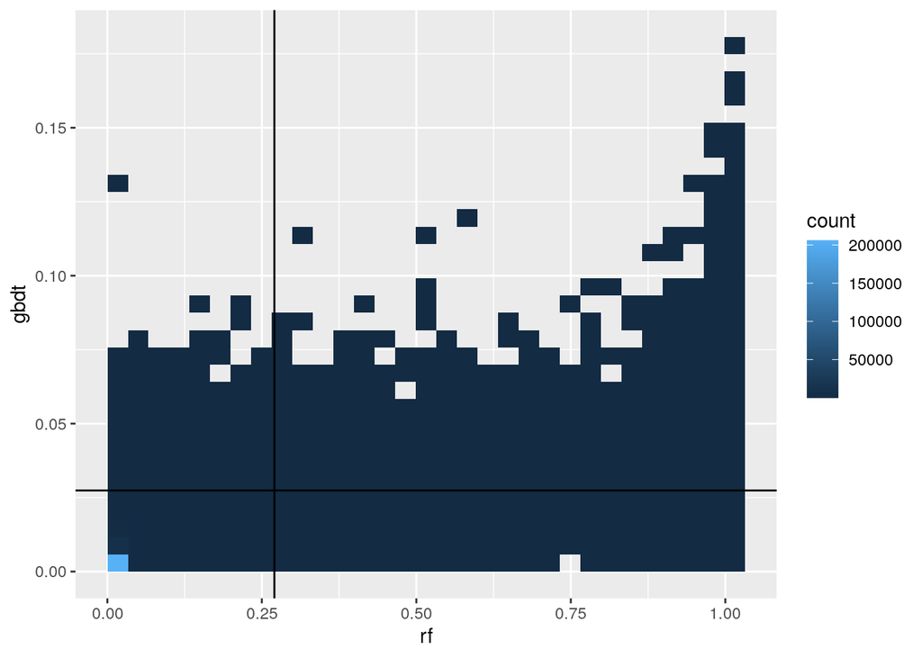

```r
ggplot(d, aes(rf,gbdt)) +
  geom_bin2d() +
  geom_hline(yintercept = mean(gbdt$res$cp)) +
  geom_vline(xintercept = mean(rf$res$cp))
```

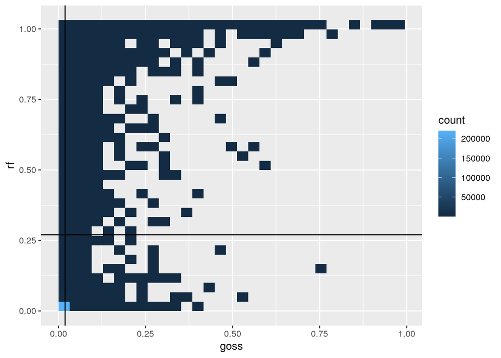

```r
ggplot(d, aes(goss,rf)) +
  geom_bin2d() +
  geom_hline(yintercept = mean(rf$res$cp)) +
  geom_vline(xintercept = mean(goss$res$cp))
```

**Eureka!** Buscando una relación entre los puntos de corte, encontramos que no todos los modelos están mandando a los mismos clientes!

Empezamos a entender que quizás debamos combinarlos, para tratar de ganar un poco más de performance.

Alguna formas simples de combinarlos son

- Si la mayoría de los modelos deciden que un elemento es `BAJA+2`, se debe enviar
- Si alguno de los modelos decide que un elemento es `BAJA+2` , se debe enviar
- Si tenemos *M* modelos, si tenemos *N* modelos, con *N < M,* que deciden que un elemento es `BAJA+2` *,* entonces se debe enviar.

**Pregunta**

- ¿Cómo podemos determinar el valor de N del punto anterior?

Otra importante observación, es que los modelos ordenan a los clientes, dejando a los clientes con un score más altos con una mayor probabilidad de que sean `BAJA+2` que los que tienen un score más bajo.

> Para los modelos, no todos los clientes son iguales

Analicemos los clientes que envía el **rf,** son en total

```r
sum(rf$probs > mean(rf$res$cp))
```

```
## [1] 7457
```

Y como es la distribución de `BAJAS+2` y `!BAJA+2`en los envíos

```r
library(dplyr)
i <- rf$probs > mean(rf$res$cp)
d2 <- data.table(probs = rf$probs[i], q = ntile(rf$probs[i], 10), clase_binaria = clase_binaria[i])
d3 <- dcast(d2, q ~ clase_binaria,
          length,
          value.var = "clase_binaria" )

d3[, ratio:= `1` / `0`]
d3[, lift:= ratio / (sum(clase_binaria) / length(clase_binaria)) ]
d3[order(-q)]
```

| q | 0 | 1 | ratio | lift |
| --- | --- | --- | --- | --- |
| 10 | 687 | 58 | 0.08442504 | 25.638413 |
| 9 | 711 | 34 | 0.04781997 | 14.522092 |
| 8 | 700 | 45 | 0.06428571 | 19.522452 |
| 7 | 719 | 27 | 0.03755216 | 11.403936 |
| 6 | 715 | 31 | 0.04335664 | 13.166657 |
| 5 | 712 | 34 | 0.04775281 | 14.501696 |
| 4 | 721 | 25 | 0.03467406 | 10.529909 |
| 3 | 725 | 21 | 0.02896552 | 8.796323 |
| 2 | 715 | 31 | 0.04335664 | 13.166657 |
| 1 | 725 | 21 | 0.02896552 | 8.796323 |

Vemos que los clientes con **score** más alto, tiene un lift 3 veces mayor que los que envía con score más bajo.

Esto nos hace pensar que desaprovechar la información de los scores podría estar cerca del pecado.

Pero ¿Cómo aprovechamos esa información? ¿Qué técnica conocemos que relaciona de forma inteligente una variable (el score es una variable) con un target?

Exacto! los modelos de machine learning! podemos relacionar los scores productos de modelos, con un nuevo modelo que seleccione en cada caso la mejor combinación.

Ensamblar resultados de modelos con otro modelo se llama **model stacking**, el modelo ensamblador se suele llamar meta-modelo.

Podemos ir un paso más, y al meta-modelo no solo darles los scores de los modelos, sino todas las variables… esto tiene aroma a lo que vimos al principio de la clase…

Pero no todo lo que brilla es oro, hay que tener cuidado de overfittear, es algo muy común cuando uno hace stacking.

Para los que decidan avanzar desde ahora en esta jungla, la idea fundamental detrás de esta estrategia, es que el entrenamiento del meta-modelo, se haga con datos de test/validation y no sobre el score del modelo de **train**. Se pueden utilizar para este fin, las funciones de **CV** que se incluyen en esta notebook.